# R Workshop on Data Manipulation & Visualization

## Objective & Topics

- Objective: present designated way of working with data in R
  - Basics tools for **Data Science**
- Topics
  - **Data Manipulation**: organize/transform/summarize/combine
  - **Data Visualization**: language for describing/creating plots

## R Resources

- Software
  - Install [R](https://cran.r-project.org/) and [RStudio](https://www.rstudio.com/) (for Linux/Windows/Mac)
  - Alternatively, use cloud version at [RStudio Cloud](https://rstudio.cloud/)
- Learning R
  - [Hands-On Programming with R](https://d1b10bmlvqabco.cloudfront.net/attach/ighbo26t3ua52t/igp9099yy4v10/igz7vp4w5su9/OReilly_HandsOn_Programming_with_R_2014.pdf), by G. Grolemund; excellent introduction to R
  - [R for Data Science](http://r4ds.had.co.nz/), by H. Wickham and G. Grolemund; **what we ’ll cover today**
  - [Advanced R](http://adv-r.had.co.nz/), by H. Wickham; gory details for serious programmers
  - [R Cheatsheets](https://www.rstudio.com/resources/cheatsheets/); for various tools/libraries

## R Overview

- R philosophy
  - Information is contained in **objects** (e.g. data, variables, models, plots)
  - Operations are represented by **functions** (e.g. sort data, fit model, plot results)
- R comes with standard functions, but can expand functionality using **packages** (a.k.a. **libraries**)
  - Packages are bundles of reusable code (functions & data)
  - Must be downloaded once w/ `install.packages()` and loaded at start of R session w/ `library()`

```r
install.packages("tidyverse")
library(tidyverse)
help(package = "tidyverse")
```

## Basic Objects

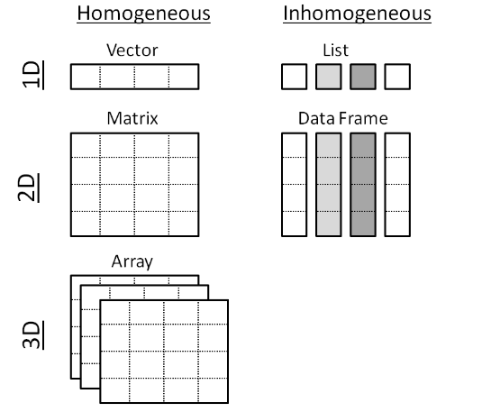

## Data Types

| Name | Description | Examples |
| --- | --- | --- |
| Logical | binary | TRUE, FALSE |
| Integer | round numbers | 1L, 45L |
| Numeric | any number | 1.234, 1e+3 |
| Character | text | “R rocks!” |
| Complex | complex numbers | 1 + 2i |
| Raw | bytes | 41 5a |

## Functions

- Functions create/modify objects according to arguments
  - E.g. Generate sequence from 3 to 5, increasing by .5

```r
seq( from = 3, to = 5, by = .5)
```

```
## [1] 3.0 3.5 4.0 4.5 5.0
```

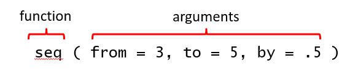

## Input/Output

- `read_delim()/read_csv()` reads tabular data (data frame) from spread-sheet like file (tab or comma delimited)

```r
my_data = read_csv( file = 'C:/Users/sdamo/Documents/data.csv')
```

- `write_delim()/write_csv()` writes tabular data (matrix or data frame) to such files
- `save()/load()` writes/reads binary (non-readable) representation of R objects
  - When closing R, `save.image()` saves all objects in `.RData` file

## Directories

- Absolute file paths (e.g. C:/Users/nmoon/…) are **bad** for reproducibility
- Use **relative** file paths, relative to your **working directory**
  - To find/set working directory use `getwd()`/`setwd()`
  - Access working directory directly

```r
getwd()
setwd("C:/Users/nmoon/...")
my_data = read_csv( file = 'data.csv')
```

- [R projects](https://support.rstudio.com/hc/en-us/articles/200526207-Using-Projects) define working directory & help organize work
- When you create an “R project” for your work, you won’t need to use `setwd()` because R will already know where to start looking for your files

## Tidy Data

In R, when we talk about **tidy** data, we mean that it is convenient for the computer to use.

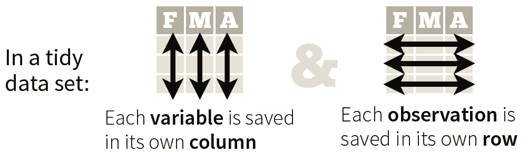

E.g.

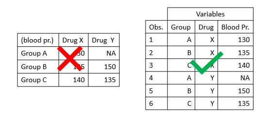

## Workshop Data

- Toronto [Dinesafe](https://www.toronto.ca/health/dinesafe/system.htm) program
  - Every food-serving establishment receives 1-3+ inspections/year
  - Public Health Inspector assigns one of 3 types of notice:

[figure not shown]

- Available through City of Toronto’s [Open Data](https://www.toronto.ca/city-government/data-research-maps/open-data/open-data-catalogue/health/#e3c15b0f-5f83-0f12-fabb-c84018395c38)

## Worksheet Time

Complete TASKS in PART 1: First look at data

## Subsetting Data

- Pick data frame obs./variables (i.e. rows/columns)

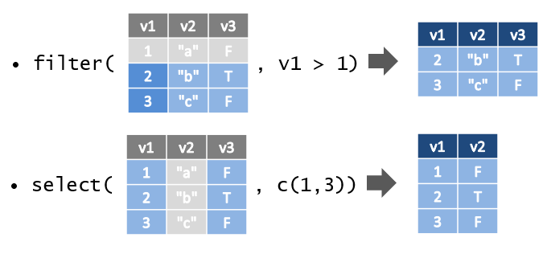

## Many other functions to extract subsets…

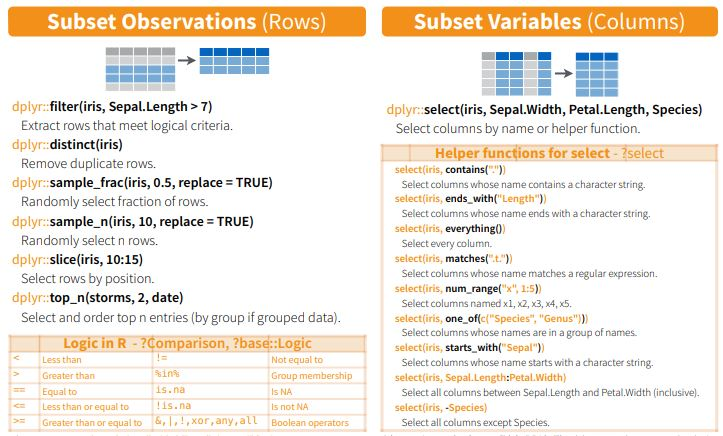

## Sorting Data

- Sort data with `arrange()`

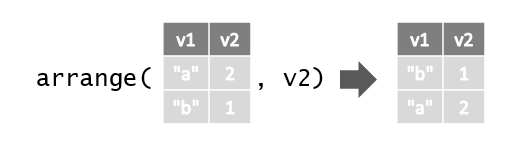

## Transforming Data

- Create new variables and summaries

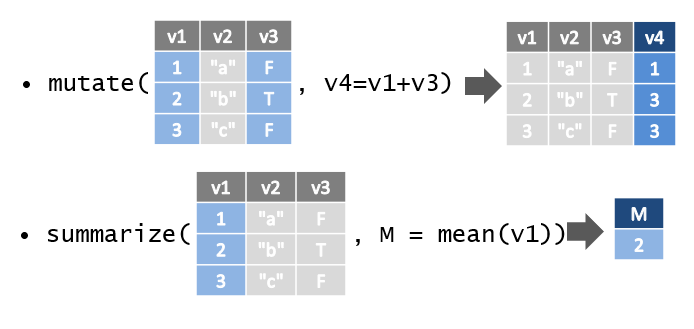

## Pipes

- Pipe operator `%>%` passes object as function’s (first) argument `x %>% f(y) = f(x, y)` or `y %>% f(x, .) = f(x, y)`
- Apply functions *sequentially*  
  `data %>% filter( ) %>% select( ) %>% summarize( )`

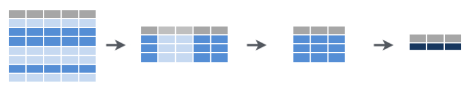

- Identical but much *easier to read* than  
  `summarize( select( filter(data) ) ) )`

## Grouping

- Apply summary functions to **groups** (i.e. subsets of data)

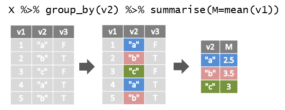

- Can group on multiple variables
  - e.g. Group on hair colour (v1) and eye colour (v2) and calculate mean height for each combination of hair/eye colour.

## Worksheet Time

Complete TASKS in PART 2: Manipulating data

## Relational Data

- Most data live on multiple *related* tables
  - Sample university database

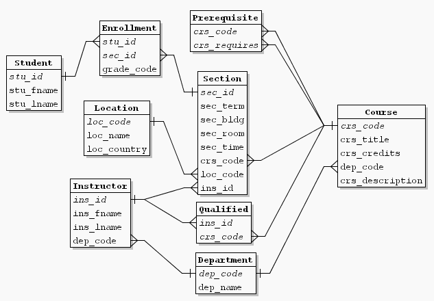

## Combining Data

- **Joins** merge data-frames by common values

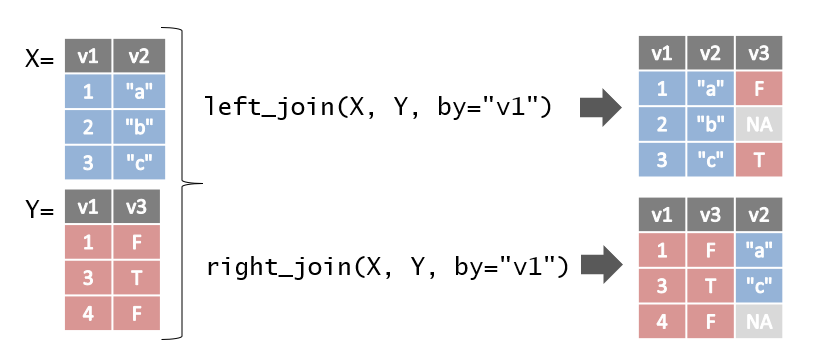

## Combining Data

- More joins

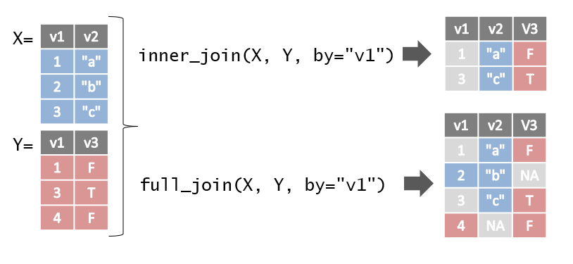

## Combining Data

- Fitering joins

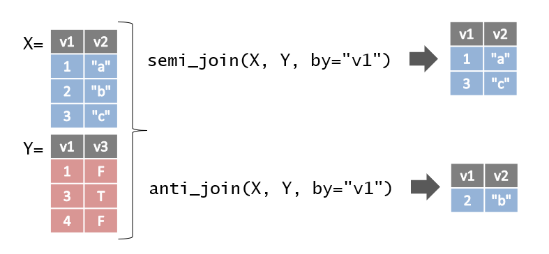

## Combining Data

- Set operations on rows (observations)

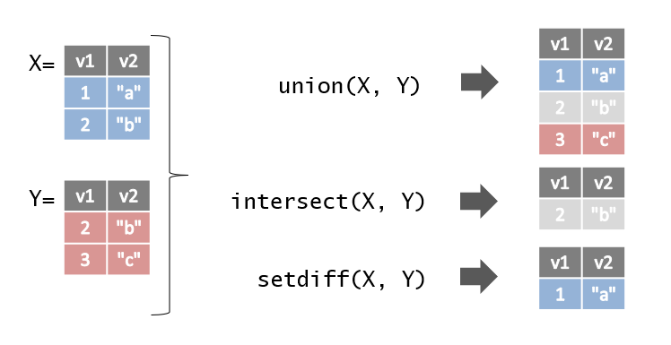

## Combining Data

- Attaching rows/columns

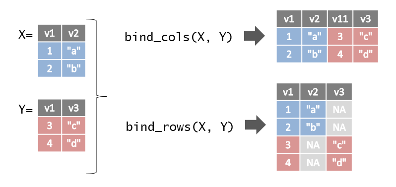

## Worksheet Time!

Complete TASKS in PART 3: Combining data

## Data Visualization

- Communicate information *graphically* through plots, charts, maps, etc.
- High-level plot description based on *layered grammar of graphics*
  - Create plots by overlaying *geometric objects* on same coordinates
- R package `ggplot2` implements such grammar for creating plots in R

## Graph Structure

- Basic ingredients
  - **Data**
  - **Aesthetic Mappings**
  - **Geometric Objects** (lines, points, text, etc)
- Extras
  - *Statistics*
  - *Scales*
  - *Facets*
  - Other adjustments (coordinates, annotations, positions)

## Graph Structure

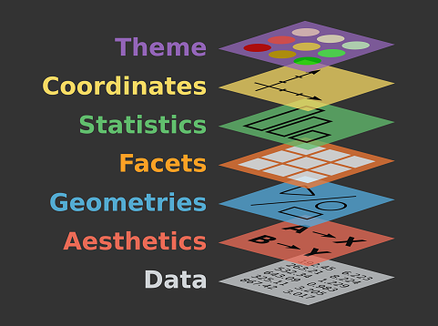

## Aesthetic Mappings

- Geometric objects convey information through their *aesthetics* (i.e. perceived characteristics)
- Data variable(s) can be *mapped* to one or more aesthetics
- Common aesthetic mappings
  - *Location*: x/y coordinates
  - *Appearance*: size, color, shape, etc

## Gapminder Data

- [Gapminder Foundation](https://www.gapminder.org/) is non-profit organization promoting world-wide social, economic and environmental development *through the use of data and statistics*
  - Excellent source of information about state of the world
- `gapminder` package provides excerpt of available [data](https://www.gapminder.org/data/)

```r
library(gapminder); glimpse(gapminder)
## Rows: 1,704
## Columns: 6
## $ country   <fct> Afghanistan, Afghanistan, Afghanistan, Afghanistan, Afgha...
## $ continent <fct> Asia, Asia, Asia, Asia, Asia, Asia, Asia, Asia, Asia, Asi...
## $ year      <int> 1952, 1957, 1962, 1967, 1972, 1977, 1982, 1987, 1992, 199...
## $ lifeExp   <dbl> 28.801, 30.332, 31.997, 34.020, 36.088, 38.438, 39.854, 4...
## $ pop       <int> 8425333, 9240934, 10267083, 11537966, 13079460, 14880372,...
## $ gdpPercap <dbl> 779.4453, 820.8530, 853.1007, 836.1971, 739.9811, 786.113...
```

## Plotting in `ggplot2`

- Basic syntax `ggplot( data, aes(...) ) + geom_*() + ...`

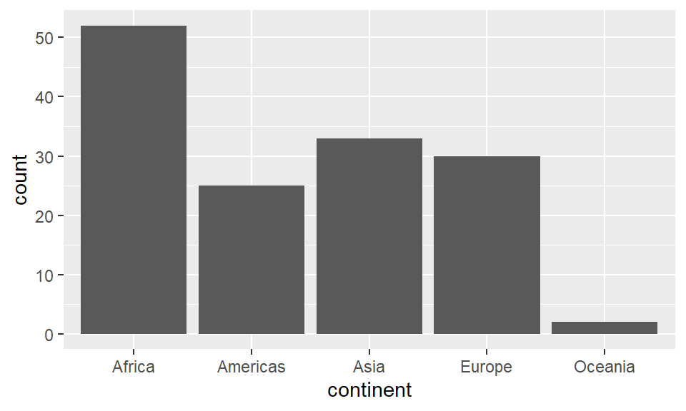

```r
gap07 <- gapminder %>% filter( year == "2007")
ggplot(gap07, aes(x = continent)) + geom_bar()
```

## Scales

- Scales control *range* of aesthetic mappings.

For example

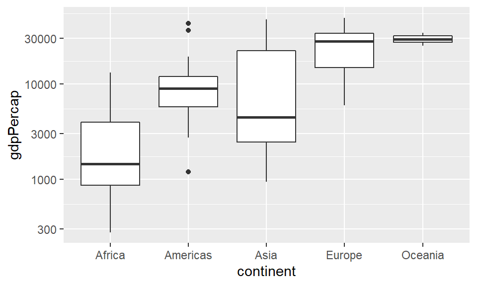

```r
ggplot(gap07, aes(x = continent, y = gdpPercap) ) +
  geom_boxplot() +
  scale_y_log10()
```

## Faceting

Use `facet_wrap()` to create grid of sub-plots, one for each level of a variable.

In the example below, we use `facet_wrap(facets = ~continent)` to create a separate plot for each continent

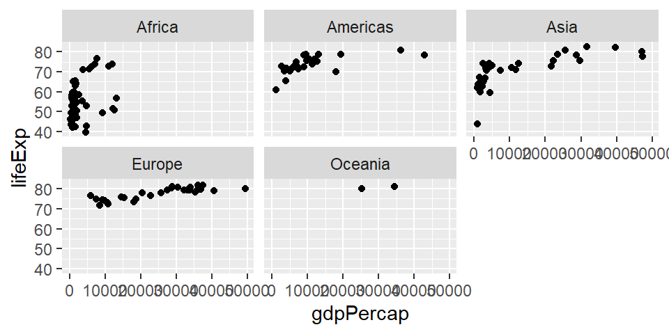

```r
ggplot(gap07, aes(x = gdpPercap, y = lifeExp)) +
  geom_point() +
  facet_wrap( facets = ~ continent)
```

## Putting this all together

Suppose you wanted to create a visualization to illustrate the population growth in each continent since 1985.

The `geom_point` geometry produces a scatterplot - this is a good choice since we’re interested in looking at the association between population (numerical) and year (numerical) across several groups (continents). The first step in creating an effective visualization is to think about the features you want.

- x-axis variable and y-axis variable?
- Are there groups within your data?
- If there are different groups, how do you want to emphasize them? (e.g. different colours? a line for each group?)
- Do you need to manipulate your dataframe to obtain the variables/groups listed above? (e.g. using `filter`, `mutate`, `group_by`, `summarize`,…)

## Putting this all together

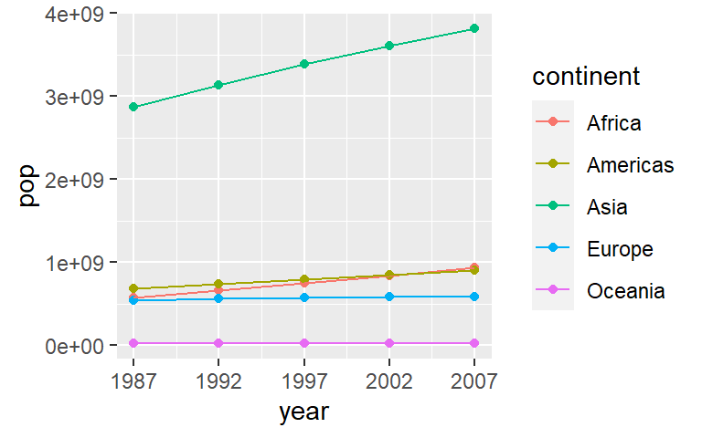

```r
gapminder %>%
  filter(year > 1985) %>%
  mutate(year=as.numeric(year), pop=as.numeric(pop)) %>%
  group_by(year, continent) %>%
  summarise(pop=sum(pop)) %>%
  ggplot(aes(x=year, y=pop, color=continent)) +
  geom_point() +
  geom_line(aes(x=year, y=pop, group=continent)) +
  scale_x_continuous(breaks=c(1987, 1992, 1997, 2002, 2007))
```

## Worksheet Time!

Complete TASKS in PART 4: Data Visualisation

## Summary

- What was covered in this document?
  - How to organize, manipulate, and visualize data in R
- Next steps:
  - Tune in to the live (virtual) workshop to further discuss these materials, the worksheet, and R more boradly. Come with your questions if you have any!
  - Use the recommended resources
  - [Practice on your own with TidyTuesday activities / DataFest virtual challenge!](https://github.com/rfordatascience/tidytuesday)

## Acknowledgements

- Many thanks to the *entire R community* for making such *amazing* tools available/accessible to everyone
  - Special thanks to Hadley Wickham [for revolutionizing R](https://priceonomics.com/hadley-wickham-the-man-who-revolutionized-r/)